# Analyzing Youtube recommender

Salma Elshahawy

11/6/2019

# Deep Neural Networks for YouTube Recommendations

YouTube represents one of the **largest scale** and most sophisticated industrial recommendation systems in existence.YouTube recommendations are responsible for helping more than a billion users discover personalized content from an ever-growing corpus of videos. Recommending YouTube videos is extremely challenging from three major perspectives:

- Scale
- Freshness
- Noise

YouTube recommender was a very interesting project for me to get deep into. Where the target users are the users - including myself, sometime I feel like they are spying on me. The key goal here is to build a YouTube recommendation and make it responsible for helping more than a billion users discover personalized content based on the user interest.

# System Overview

The system is comprised of two neural networks: one for *candidate generation* and one for *ranking*. The **candidate generation** network takes events from the user’s YouTube activity history as input and retrieves a small subset (hundreds) of videos from a large corpus.

## CANDIDATE GENERATION

The candidate generation network only provides broad personalization via collaborative filtering.The similarity between users is expressed in terms of coarse features such as IDs of video watches, search query tokens and demographics. Presenting a few “best” recommendations in a list requires a fine-level representation to distinguish relative importance among candidates with high recall. The ranking network accomplishes this task by assigning a score to each video according to a desired objective function using a rich set of features describing the video and user. The highest scoring videos are presented to the user, ranked by their score.

### Recommendation as Classification

Recommendation considered as extreme multiclass classification where the prediction problem becomes accurately classifying a specific video watch $wt$ at time $t$ among millions of videos $i$ (classes) from a corpus $V$ based on a user $U$ and context $C$

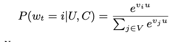

The task of the deep neural network is to learn user embeddings u as a function of the user’s history and context that are useful for discriminating among videos with a softmax classifier.

### Model Architecture

Inspired by continuous bag of words language models, we learn high dimensional embeddings for each video in a fixed vocabulary and feed these embeddings into a feedforward neural network. A user’s watch history is represented by a variable-length sequence of sparse video IDs which is mapped to a dense vector representation via the embeddings.

### Heterogeneous Signals

A key advantage of using deep neural networks as a generalization of matrix factorization is that arbitrary continuous and categorical features can be easily added to the model. Search history is treated similarly to watch history - each query is tokenized into unigrams and bigrams and each token is embedded. Once averaged, the user’s tokenized, embedded queries represent a summarized dense search history. Demographic features are important for providing priors so that the recommendations behave reasonably for new users. The user’s geographic region and device are embedded and concatenated. Simple binary and continuous features such as the user’s gender, logged-in state and age are input directly into the network as real values normalized to [0, 1].

### Label and Context Selection

It is important to emphasize that recommendation often involves solving a surrogate problem and transferring the result to a particular context. It is important to emphasize that recommendation often involves solving a surrogate problem and transferring the result to a particular context. We have found that the choice of this surrogate learning problem has an outsized importance on performance in A/B testing but is very difficult to measure with offline experiments. Training examples are generated from all YouTube watches (even those embedded on other sites) rather than just watches on the recommendations we produce. Otherwise, it would be very difficult for new content to surface and the recommender would be overly biased towards exploitation. If users are discovering videos through means other than our recommendations, we want to be able to quickly propagate this discovery to others via collaborative filtering. Another key insight that improved live metrics was to generate a fixed number of training examples per user, effectively weighting our users equally in the loss function.

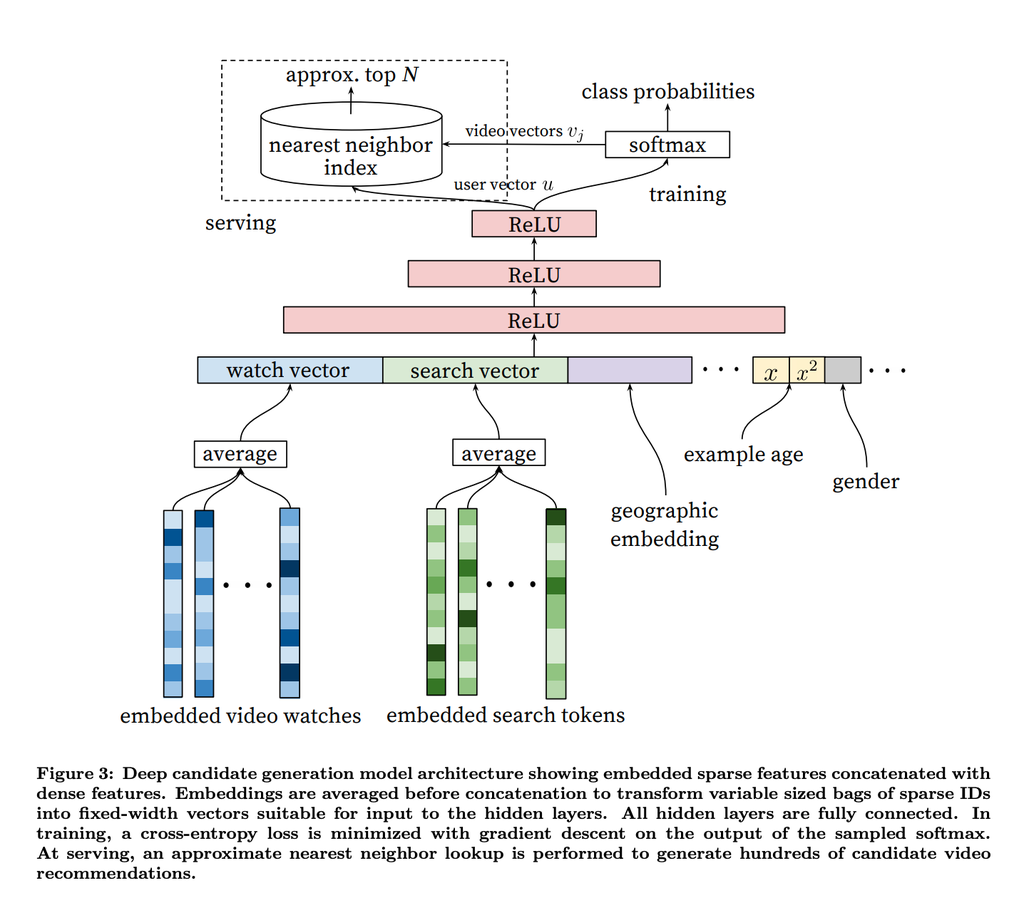

### Experiments with Features and Depth

Adding features and depth significantly improves precision on holdout data. In these experiments, a vocabulary of 1M videos and 1M search tokens were embedded with 256 floats each in a maximum bag size of 50 recent watches and 50 recent searches. The softmax layer outputs a multinomial distribution over the same **1M** video classes with a dimension of 256 (which can be thought of as a separate output video embedding). These models were trained until convergence over all YouTube users, corresponding to several epochs over the data.

[figure not shown]

## RANKING

The primary role of ranking is to use impression data to specialize and calibrate candidate predictions for the particular user interface. For example, a user may watch a given video with high probability generally but is unlikely to click on the specific homepage impression due to the choice of thumbnail image. The list of videos is then sorted by this score and returned to the user. Our final ranking objective is constantly being tuned based on live A/B testing results but is generally a simple function of expected watch time per impression. Ranking by click-through rate often promotes deceptive videos that the user does not complete (“clickbait”) whereas watch time better captures engagement.

### Feature Representation

Typically hundreds of features in our ranking models, roughly split evenly between categorical and continuous. Despite the promise of deep learning to alleviate theburden of engineering features by hand, the nature of the raw data does not easily lend itself to be input directly into feedforward neural networks.

### Modeling Expected Watch Time

Our goal is to predict expected watch time given training examples that are either positive (the video impression was clicked) or negative (the impression was not clicked). Positive examples are annotated with the amount of time the user spent watching the video. To predict expected watch time we use the technique of weighted logistic regression, which was developed for this purpose. The model is trained with logistic regression under crossentropy loss. However, the positive (clicked) impressions are weighted by the observed watch time on the video. Negative (unclicked) impressions all receive unit weight.

### Experiments with Hidden Layers

The value shown for each configuration (“weighted, per-user loss”) was obtained by considering both positive (clicked) and negative (unclicked) impressions shown to a user on a single page.

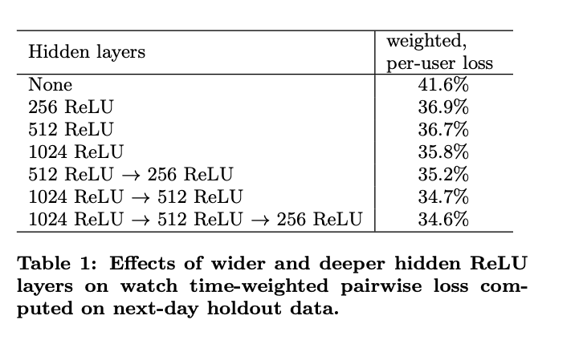

If the negative impression receives a higher score than the positive impression, then the positive impression’s watch time considered to be mispredicted watch time. Weighted, peruser loss is then the total amount mispredicted watch time as a fraction of total watch time over heldout impression pairs. These results show that increasing the width of hidden layers improves results, as does increasing their depth.

# Conclusion

The deep collaborative filtering model is able to effectively assimilate many signals and model their interaction with layers of depth, outperforming previous matrix factorization approaches used at YouTube. Ranking is a more classical machine learning problem yet where the deep learning approach outperformed previous linear and tree-based methods for watch time prediction. Recommendation systems in particular benefit from specialized features describing past user behavior with items. Logistic regression was modified by weighting training examples with watch time for positive examples and unity for negative examples, allowing us to learn odds that closely model expected watch time. This approach performed much better on watch-time weighted ranking evaluation metrics compared to predicting click-through rate directly.

# References

- [Deep Neural Networks for YouTube Recommendations by Paul Covington, Jay Adams, Emre Sargin ,Google, Mountain View, CA](https://static.googleusercontent.com/media/research.google.com/en//pubs/archive/45530.pdf)
- [GitHub repo](https://github.com/salma71/MSDS_2019/tree/master/Fall2019/aquisition_management_607/week_11)